# W05 — Korelacja, regresja i raport ilościowy

Zarządzanie informacją — część ilościowa — 2026/27

Marek Deja

2026/27

Wykład W05 łączy dwa wyniki tej samej osoby: korelacją, regresją prostą i kalibracją, a potem przekłada wynik na akapit raportu. Skrypt `analiza.R` zapisany w folderze wykładu liczy przykłady i rysuje wykresy; kod skryptu pozostaje ukryty. Dane sześciu osób są hipotetyczne i przygotowane dla wykładu, aby każdą parę dało się prześledzić ręcznie. Każdy wykres ma w tekście słowny opis osi, wartości i wniosku.

# Dwie osoby, dwa rodzaje dowodów

Bibliotekarka słyszy: „katalog jest dla mnie łatwy”. Następnie obserwuje, jak ta sama osoba szuka dokumentu przez kilkanaście minut. Długi czas ma trzy wyjaśnienia zgodne z trafną deklaracją: trudne zadanie, dokładna weryfikacja źródła i dobre wsparcie złożonego wyszukiwania. Zestawienie odpowiedzi z zachowaniem otwiera pytanie badawcze.

Zbiór S02 zawiera indeks deklarowanej użyteczności katalogu, czas i powodzenie zadania. Indeks S02 zachowuje w całym wykładzie znaczenie deklarowanej użyteczności katalogu; samoocenę umiejętności i jej kalibrację omawia osobny przykład w części „Kalibracja samooceny: zgodność poziomów”.

Korelacja opisuje współzmienność. Regresja prosta opisuje przewidywaną średnią jednego wyniku przy danym poziomie drugiej zmiennej. Zgodność dwóch pomiarów dotyczy równości ich poziomów. Wniosek o mechanizmie przyczynowym wymaga projektu przyczynowego dla każdego z trzech rachunków.

# Trzy źródła danych w badaniach LIS: log, ankieta i obserwacja

Hargittai (2002) zestawia informacje o zachowaniu internetowym z różnymi sposobami pomiaru umiejętności. Każde z trzech źródeł mierzy wycinek kompetencji: log — zdarzenia zapisane przez system, ankieta — deklaracje, obserwacja — działanie w określonym zadaniu.

Internet Skills Scale van Deursena, Helsper i Eynona porządkuje obszary samoopisu umiejętności, a DigComp 2.2 i ACRL dostarczają języka obszarów kompetencji i praktyk informacyjnych. Odwołanie do ISS, DigComp 2.2 i ACRL wspiera uzasadnienie operacjonalizacji; walidacja autorskiego zestawu pytań wymaga osobnego badania.

Transformacja cyfrowa biblioteki zmienia jednocześnie interfejs, dostęp do zasobów, wymagania wobec użytkowników i organizację wsparcia. Spadek czasu wyszukiwania po zmianie interfejsu i organizacji wsparcia prowadzi do trzech pytań: kto pozostał użytkownikiem, jakie zadania wykonywano i czy definicja czasu pozostała taka sama. Wiedza o transformacji instytucji dostarcza kontekstu do odczytu wyniku statystycznego.

Pytanie wykładu brzmi: czy wyższa deklarowana ocena katalogu współwystępuje z krótszym obserwowanym czasem? Ujemny znak współczynnika byłby zgodny ze współwystępowaniem wyższej oceny z krótszym czasem. Krótszy czas oznacza lepsze wykonanie przy zakończonym sukcesie; szybkie porzucenie zadania też skraca czas, więc raport czyta czas obok powodzenia.

# Pary, populacja i estymanda

Obserwacją jest osoba z parą $(x_i,y_i)$: $x$ oznacza indeks użyteczności, a $y$ — czas w minutach. Para łączy dwa wyniki tej samej osoby w jednym wierszu.

Dla korelacji Pearsona estymandą jest populacyjna korelacja liniowa $\rho_P$, a estymatą — współczynnik z próby $r$. Dla Spearmana estymandą jest korelacja rangowa $\rho_S$, estymowana przez $r_S$. Programy podpisują czasem współczynnik Spearmana z próby literą $\rho$; wykład używa $r_S$ dla próby i $\rho_S$ dla populacji.

Dla regresji estymandą jest nachylenie $\beta_1$ prostej średniego czasu (model w części „Regresja: zmiana przewidywanej średniej”). Jednostką nachylenia są minuty na punkt indeksu, a korelacja jest liczbą bez jednostki: pierwsza wielkość opisuje zmianę w naturalnych jednostkach pomiaru, druga — siłę związku po standaryzacji.

Braki prowadzą do liczby kompletnych par, mniejszej lub równej liczbie ważnych indeksów i liczbie ważnych czasów. Usuwanie braków obejmuje cały wiersz, więc pary zachowują osoby.

## Oznaczenia wykładu W05

Oznaczenia wykładu W05

| Symbol | Znaczenie |
| --- | --- |
| $x_i$, $y_i$, $\bar{x}$, $\bar{y}$, $s_x$, $s_y$ | Wyniki osoby $i$; średnie i SD obu zmiennych |
| $s_{xy}$, $r$, $\rho_P$ | Kowariancja z próby; korelacja Pearsona z próby i w populacji |
| $r_S$, $\rho_S$, $D_i$, $S$ | Korelacja Spearmana z próby i w populacji; różnica rang osoby; suma $D_i^2$ |
| $z_r$ | Transformacja Fishera współczynnika $r$ |
| $\beta_0$, $\beta_1$, $b_0$, $b_1$ | Wyraz wolny i nachylenie w populacji; ich estymaty |
| $E(Y\mid X=x)$, $\varepsilon_i$ | Średnia Y wśród osób z X = x; odchylenie osoby od średniej warunkowej |
| $\widehat{y}_i$, $e_i$, $s_e$ | Wartość przewidywana; reszta $y_i-\widehat{y}_i$; SD reszt |
| $R^2$, $SSE$, $SST$ | Współczynnik determinacji; suma kwadratów reszt; suma kwadratów od średniej |
| $h_i$, $D^{C}_i$ | Dźwignia osoby; odległość Cooka |
| $B$, $\#$ | Liczba powtórzeń; liczba przypadków spełniających warunek |

# Wykres poprzedza współczynnik

Punkt na wykresie rozrzutu przedstawia dwa wyniki tej samej osoby. Odczyt obejmuje kierunek, kształt, skupienia, zakres i nietypowe punkty. Linia przedstawia średni czas przewidywany przy danej ocenie, a pasmo wokół linii — 95% przedział ufności średniej warunkowej.

Kwartet Anscombe’a uzasadnia zasadę „wykres przed współczynnikiem”: cztery zbiory po 11 par mają prawie te same średnie, wariancje, korelację 0,82 i prostą regresji.

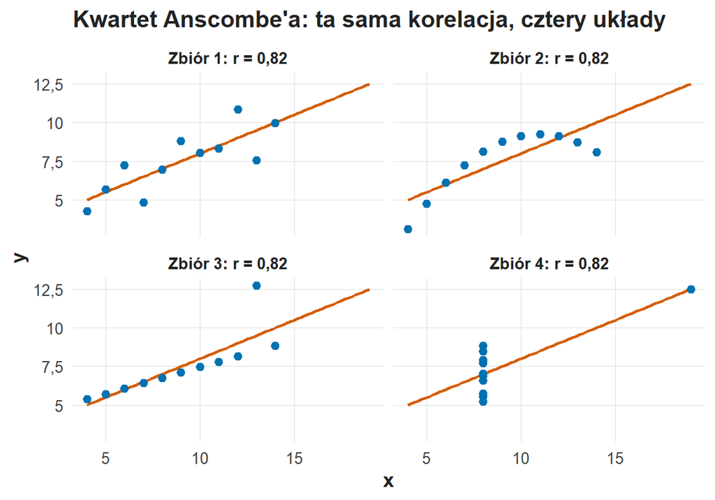

Kwartet Anscombe’a: ta sama korelacja, cztery układy. Cztery panele, w każdym 11 punktów i ta sama prosta regresji; r = 0,82 we wszystkich zbiorach. Zbiór 1: chmura punktów wokół prostej. Zbiór 2: punkty na łuku. Zbiór 3: punkty na prostej z jednym punktem wysoko nad nią. Zbiór 4: dziesięć punktów w pionowej kolumnie przy x = 8 i jeden punkt przy x = 19.

W małej demonstracji sześć osób (a–f) podało ocenę 1–5 i wykonało zadanie. Tabela „Sześć par” podaje oceny x = 1, 2, 2, 3, 4, 5 i czasy y = 15, 12, 14, 10, 9, 6 minut. Dane są dobrane do przedstawienia wyraźnej tendencji; zbiór S02 analizowany w ćwiczeniu C08 (Samoocena a wykonanie: korelacja, permutacja i prosta regresja) ma związek znacznie słabszy: 141 par, r = −0,126, $r_S$ = −0,136.

Sześć par: ocena i czas

| Osoba | x: ocena 1–5 | y: czas [min] |
| --- | --- | --- |
| a | 1 | 15 |
| b | 2 | 12 |
| c | 2 | 14 |
| d | 3 | 10 |
| e | 4 | 9 |
| f | 5 | 6 |

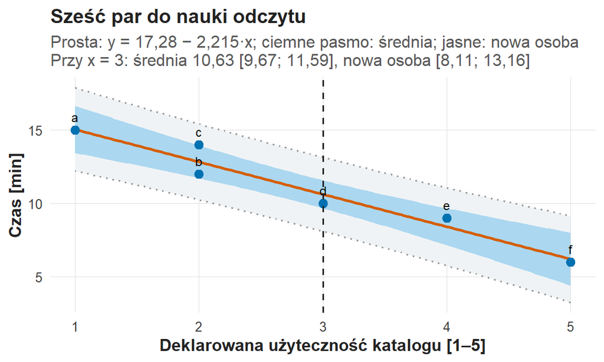

Sześć par do nauki odczytu. Oś pozioma: deklarowana użyteczność katalogu 1–5; oś pionowa: czas w minutach. Sześć punktów a–f układa się wzdłuż malejącej prostej od 15 minut przy x = 1 do 6 minut przy x = 5; przy x = 2 leżą dwa punkty, 12 i 14 minut. Ciemne pasmo wokół prostej to 95% przedział średniej warunkowej, jasne — 95% przedział predykcji; linia przerywana przy x = 3 wskazuje średnią 10,63 minuty.

Dwa czasy przy ocenie 2, 12 i 14 minut, oznaczają, że ocena wyznacza czas z rozrzutem: osoby o tej samej ocenie działają różnie także przy silnym związku ogólnym.

# Czytamy kowariancję i r

$$s_{xy}=\frac{\sum_{i=1}^n(x_i-\bar x)(y_i-\bar y)}{n-1},
\qquad
r=\frac{s_{xy}}{s_xs_y}.$$

Najpierw ustala się, czy wynik każdej zmiennej leży powyżej, czy poniżej swojej średniej. Iloczyn dwóch odchyleń jest dodatni przy tych samych znakach i ujemny przy przeciwnych; uśrednienie iloczynów opisuje kierunek współzmienności. Tabela „Odchylenia od średnich i ich iloczyny” podaje odchylenia od średnich ($\bar{x}=2{,}83$, $\bar{y}=11$) i ich iloczyny. Wszystkie sześć iloczynów jest ujemnych, od −0,17 (osoba d) do −10,83 (osoba f); suma wynosi −24, więc $s_{xy}=-24/5=-4{,}8$.

Odchylenia od średnich i ich iloczyny

| Osoba | x − 2,83 | y − 11 | Iloczyn |
| --- | --- | --- | --- |
| a | −1,83 | 4 | −7,33 |
| b | −0,83 | 1 | −0,83 |
| c | −0,83 | 3 | −2,50 |
| d | 0,17 | −1 | −0,17 |
| e | 1,17 | −2 | −2,33 |
| f | 2,17 | −5 | −10,83 |
| Suma | 0,00 | 0 | −24,00 |

Kowariancja ma jednostkę będącą iloczynem jednostek x i y. Podzielenie jej przez iloczyn SD usuwa jednostki: $r=-4{,}8/(1{,}472\cdot3{,}347)=-0{,}974$, wartość z zakresu od −1 do 1. Przeliczenie minut na sekundy pozostawia r bez zmian i zmienia kowariancję oraz nachylenie wyrażone w jednostkach czasu.

$r=-1$ opisuje punkty leżące dokładnie na malejącej prostej. Znak zależy od kierunku skal: zamiana czasu na wskaźnik sprawności, w którym większa liczba oznacza szybsze działanie, odwraca znak przy tym samym zachowaniu.

$r=0$ oznacza zerową liniową współzmienność; zależność w kształcie U daje $r=0$ i $r_S=0$ (wykres „Zależność monotoniczna i zależność w kształcie U”). Współczynnik wymaga zmienności obu zmiennych, a wąski zakres ocen ogranicza możliwość obserwowania związku obecnego w bardziej zróżnicowanej populacji. Wykres „Cztery wartości r” kalibruje odczyt współczynnika.

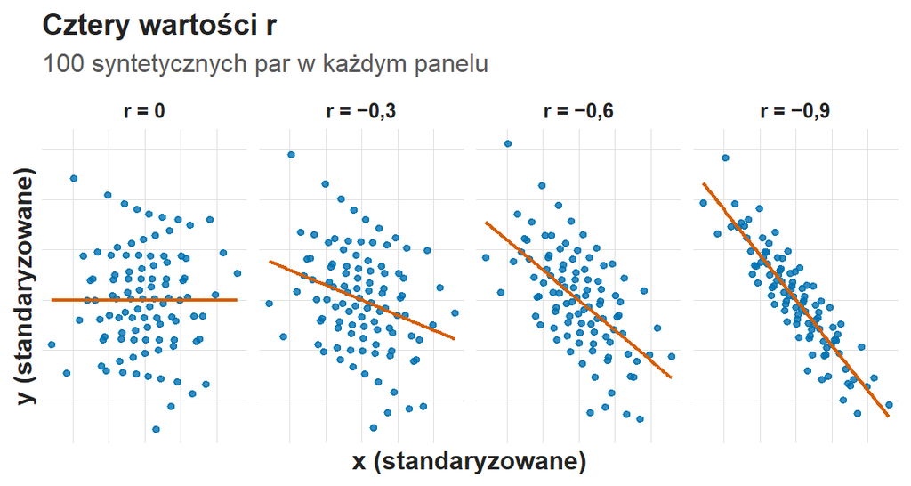

Cztery wartości r: cztery panele po 100 syntetycznych par o r = 0; −0,3; −0,6 i −0,9 z prostą regresji. Przy r = 0 chmura jest okrągła, a prosta pozioma; przy r = −0,3 szeroka chmura ma lekki spadek; przy r = −0,6 chmura jest wyraźnie wydłużona; przy r = −0,9 punkty tworzą wąskie pasmo wzdłuż malejącej prostej.

# Rangi i monotoniczność

Spearman to korelacja Pearsona obliczona na rangach. Ranga określa pozycję w uporządkowanym zbiorze; osoby b i c z x = 2 zajmują miejsca drugie i trzecie, więc otrzymują średnią rangę 2,5. Rangi zachowują kolejność wartości: czasy 6 i 9 minut dostają rangi 1 i 2 niezależnie od odstępu, a przedmiotem opisu staje się zgodność kolejności.

Bez remisów współczynnik Spearmana ma postać skróconą:

$$r_S=1-\frac{6\sum_{i=1}^{n}D_i^2}{n(n^2-1)},$$

Rangi sześciu par

| Osoba | x | Ranga x | y | Ranga y | D = różnica rang |
| --- | --- | --- | --- | --- | --- |
| a | 1 | 1,0 | 15 | 6 | −5,0 |
| b | 2 | 2,5 | 12 | 4 | −1,5 |
| c | 2 | 2,5 | 14 | 5 | −2,5 |
| d | 3 | 4,0 | 10 | 3 | 1,0 |
| e | 4 | 5,0 | 9 | 2 | 3,0 |
| f | 5 | 6,0 | 6 | 1 | 5,0 |

Wybór metody wynika z pytania, skali i kształtu związku. Obliczenie r wymaga par liczb; klasyczny test i przedział dodają założenie normalności. Krzywa monotoniczna daje $r=-0{,}82$ i $r_S=-1$; kształt U daje $r=0$ i $r_S=0$ przy regularnej zależności.

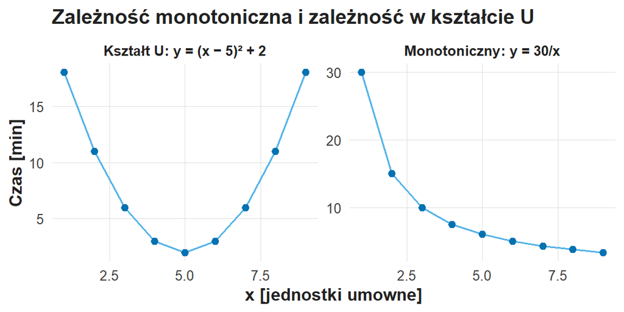

# Klasyczny test i przedział korelacji

Dla testu $H_0:\rho_P=0$ używa się statystyki:

$$t=r\sqrt{\frac{n-2}{1-r^2}},\qquad df=n-2.$$

Licznik odzwierciedla wielkość współczynnika i liczbę par, a mianownik — jego ograniczony zakres; większe $|r|$ przy tym samym N przesuwa statystykę dalej od zera. W klasycznym modelu niezależnych par z rozkładu normalnego dwóch zmiennych (każda zmienna ma rozkład normalny, a związek jest liniowy) statystyka ma przy hipotezie zerowej rozkład t. Niezależność dotyczy par różnych osób; związek x i y w parze jest przedmiotem badania. Wielokrotne sesje jednej osoby wymagają modelu z osobą jako jednostką.

Przedział dla $\rho_P$ powstaje z transformacji Fishera, której rozkład jest bliski normalnemu:

$$z_r=\tfrac12\ln\frac{1+r}{1-r},\qquad SE(z_r)=\frac{1}{\sqrt{n-3}},\qquad z_r\pm1{,}96\,SE(z_r)\ \xrightarrow{\ \tanh\ }\ [\rho_{\mathrm{dol}};\ \rho_{\mathrm{góra}}].$$

Dla $r=-0{,}974$ i $n=6$: $z_r=-2{,}173$, $SE=0{,}577$, granice $-3{,}304$ i $-1{,}041$, a po przekształceniu funkcją $\tanh$ — przedział [−0,997; −0,778]. Tabela „Korelacja sześciu par” podaje $r=-0{,}974$, $t(4)=-8{,}668$, $p=0{,}0010$, przedział z transformacji Fishera i $r_S=-0{,}986$; przedział z transformacji Fishera dotyczy $\rho_P$.

Korelacja sześciu par

[output not shown]

Przedział Pearsona [−0,997; −0,778] opisuje precyzję w sześciu celowo dobranych parach; zakres uogólnienia wyznacza dobór próby. Wynik Spearmana raportuje się jako $r_S$, statystykę S, przybliżone p i przedział bootstrapowy.

# Permutacja: zmiana parowania przy stałych rozkładach

Przy hipotezie niezależności i wymienialności oceny pozostają na miejscu, a czasy przestawia się między osobami. Zbiór ocen i zbiór czasów pozostają takie same, a pierwotne powiązanie znika. Dla każdego ustawienia oblicza się współczynnik wybrany przed analizą; test dwustronny liczy układy z $|r^*|\ge|r|$, czyli oba ogony.

Sześć czasów ma $6!=6\cdot5\cdot4\cdot3\cdot2\cdot1=720$ ustawień, a 720 układów tworzy pełny rozkład warunkowy. Remisy x sprawiają, że różne ustawienia dają ten sam współczynnik; każde ustawienie wchodzi do wyliczenia:

$$p=\frac{\#\{|r^*|\ge|r|\}}{6!}=\frac{4}{720}=0,0056 .$$

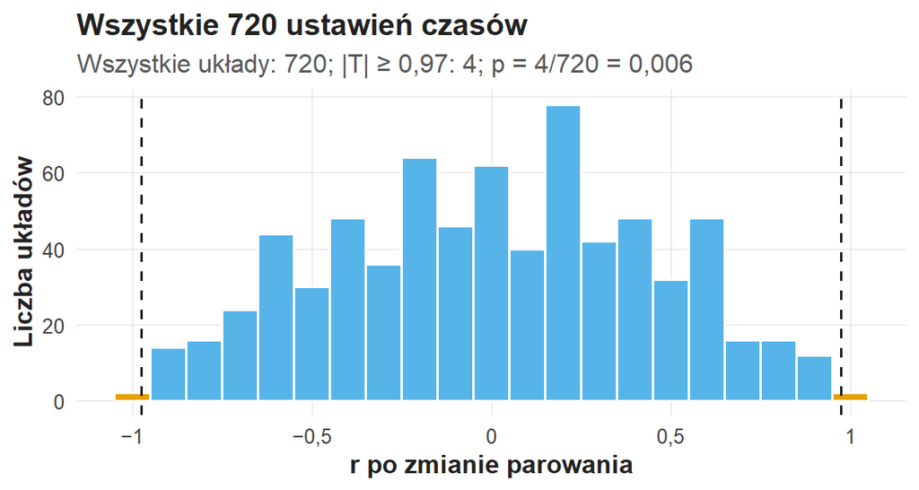

Pełne wyliczenie daje p jako udział skrajnych układów: $4/720=0{,}0056$; poprawka +1 należy do przybliżenia Monte Carlo. Przy większej liczbie osób losuje się $B$ układów i stosuje $p_{\mathrm{MC}}=(1+\#\{|r^*_b|\ge|r|\})/(B+1)$, jak w wykładzie W03. Klasyczne p (0,0010) i permutacyjne p (0,0056) korzystają z różnych rozkładów odniesienia.

Permutacja zakłada wymienialność par przy $H_0$; klastry i powtarzane pomiary wymagają przestawień w obrębie bloków. Test permutacyjny sprawdza niezależność par, a test t — zerową korelację liniową; przy rozkładzie normalnym dwóch zmiennych hipotezy są równoważne.

# Bootstrap: pary pozostają parami

Bootstrap osób losuje z powtórzeniami całe wiersze $(x_i,y_i)$. Jedna osoba może wystąpić kilka razy, a jej ocena pozostaje połączona z jej czasem. Bootstrap losuje całe pary i zachowuje relację wewnątrz osoby; permutacja celowo zmienia parowanie pod modelem zerowym.

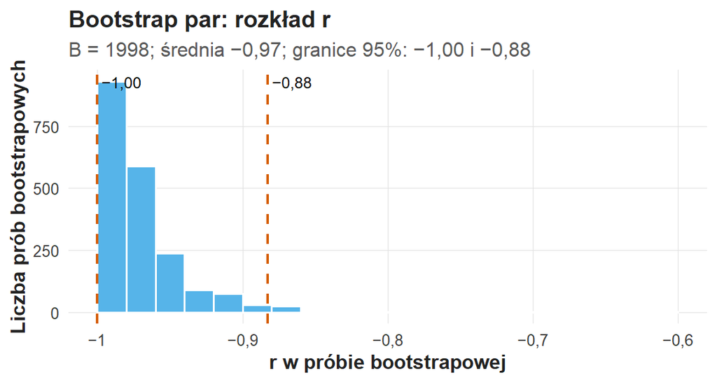

Percentylowy bootstrap jest przybliżeniem. Przy sześciu parach rozkład bootstrapowy jest ucięty na granicy parametru, −1, a jedna z 1999 replik ma wszystkie x równe i nieokreślony współczynnik. Ćwiczenie C08 podaje liczbę replik z obliczonym współczynnikiem.

# Regresja: zmiana przewidywanej średniej

Model zapisujemy jako:

$$Y_i=\beta_0+\beta_1x_i+\varepsilon_i,
\qquad E(Y\mid X=x)=\beta_0+\beta_1x .$$

Pierwsza postać zawiera odchylenie osoby od średniej warunkowej, a druga postać opisuje średnią warunkową. Metoda najmniejszych kwadratów (ang. *ordinary least squares*, OLS) dobiera prostą $\widehat y=b_0+b_1x$ minimalizującą sumę kwadratów reszt $e_i=y_i-\widehat y_i$:

$$b_1=\frac{s_{xy}}{s_x^2}=r\,\frac{s_y}{s_x}=\frac{-4{,}8}{2{,}167}=-2{,}215,\qquad b_0=\bar y-b_1\bar x=11+2{,}215\cdot2{,}833=17{,}28 .$$

Duże odchylenia wpływają na sumę kwadratów silniej, więc punkt nietypowy zmienia nachylenie; decyzja o punkcie nietypowym opiera się na sprawdzeniu rekordu. Korelacja opisuje siłę standaryzowaną, a nachylenie przywraca jednostki. Zamiana ról x i y pozostawia r bez zmian i daje inny model: nachylenie regresji x na y wynosi $r\,s_x/s_y=-0{,}429$, a iloczyn obu nachyleń równa się $r^2=0{,}949$.

Błąd standardowy nachylenia i statystyka t mają postać:

$$SE(b_1)=\frac{s_e}{\sqrt{\sum(x_i-\bar{x})^2}}=\frac{0{,}841}{\sqrt{10{,}83}}=0{,}256,\qquad t=\frac{b_1}{SE(b_1)}=-8{,}668 ,$$

tyle samo co t korelacji: w regresji prostej oba testy są tożsame. Tabela „Regresja czasu na ocenę” podaje wyraz wolny 17,28 (SE 0,80), nachylenie −2,215 minuty na punkt (SE 0,256), $t(4)=-8{,}668$, $p=0{,}0010$ i 95% CI nachylenia [−2,93; −1,51]. Klasyczne SE i przedziały zakładają poprawną liniową średnią, niezależność i stałą wariancję błędu; wnioskowanie t w małej próbie dodaje normalność błędów.

Regresja czasu na ocenę

| Parametr | Estymata | SE | t | df | p | 95% CI |
| --- | --- | --- | --- | --- | --- | --- |
| Wyraz wolny b0 [min] | 17,277 | 0,801 | 21,556 | 4 | < 0,0001 | [15,05; 19,50] |
| Nachylenie b1 [min na punkt] | −2,215 | 0,256 | −8,668 | 4 | 0,0010 | [−2,93; −1,51] |

Osoby różniące się o jeden punkt indeksu mają w modelu średni przewidywany czas różniący się o −2,22 minuty. Nachylenie porównuje osoby o różnych ocenach; skutek zmiany oceny tej samej osoby wymaga eksperymentu.

Wyraz wolny wyznacza położenie prostej przy x = 0, poza skalą 1–5. Wycentrowanie x wokół 3 daje wyraz wolny równy prognozie przy x = 3:

$$x^{c}=x-3,\qquad \widehat{y}=10{,}63-2{,}215\,x^{c},$$

a nachylenie pozostaje takie samo.

# R-kwadrat i reszty

$$R^2=1-\frac{\sum(y_i-\widehat y_i)^2}{\sum(y_i-\bar y)^2}=1-\frac{SSE}{SST}=1-\frac{2{,}83}{56}=0{,}949=(-0{,}974)^2 .$$

Wzór porównuje błąd modelu z błędem przewidywania wszystkim tą samą średnią. $R^2=0{,}949$ oznacza, że 94,9% sumy kwadratów odchyleń czasu od średniej przypada na prostą regresji; w regresji prostej $R^2=r^2$. Znaczenie praktyczne ocenia się po nachyleniu w minutach na punkt. SD reszt 0,84 minuty opisuje typową odległość punktu od prostej. Tabela „Dopasowanie prostej” podaje $R^2$, SD reszt, SSE i SST.

Dopasowanie prostej

| Wielkość | Wartość |
| --- | --- |
| R² | 0,949 |
| SD reszt s_e [min] | 0,841 |
| SSE (suma kwadratów reszt) | 2,83 |
| SST (suma kwadratów od średniej) | 56 |

Diagnostyka wraca do danych. Wykres reszt wobec wartości przewidywanych ujawnia krzywiznę (niedopasowana średnia) i lejek (rozrzut zależny od poziomu przewidywania).

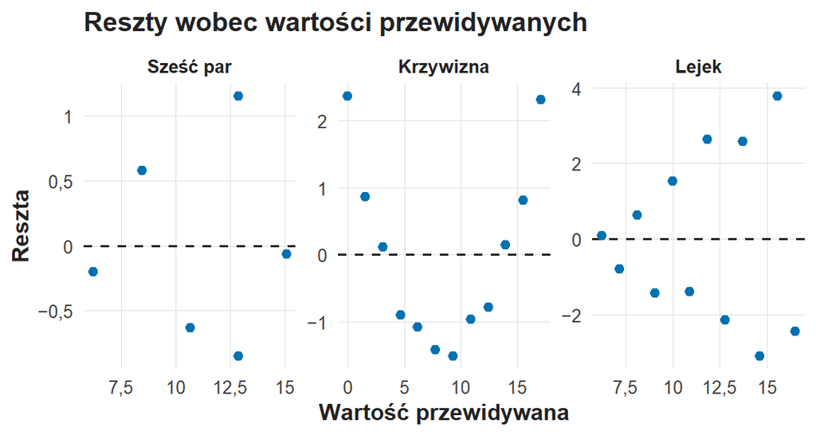

Reszty wobec wartości przewidywanych w trzech panelach; linia przerywana to zero. Sześć par: reszty od −0,85 do 1,15 minuty, rozrzucone wokół zera. Krzywizna (dane demonstracyjne): reszty tworzą łuk — dodatnie na obu końcach, ujemne w środku. Lejek (dane demonstracyjne): rozrzut reszt rośnie z wartością przewidywaną.

Wykres kwantylowy dotyczy kształtu rozkładu reszt i zestawia uporządkowane reszty z kwantylami rozkładu normalnego, jak w wykładzie W04 (Porównania grup i zależności kategorii).

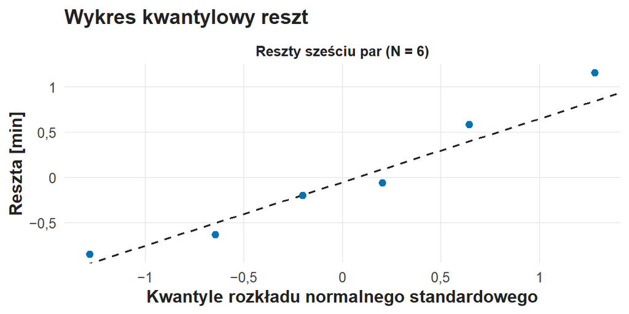

Wykres kwantylowy reszt sześciu par. Oś pozioma: kwantyle rozkładu normalnego standardowego; oś pionowa: reszty w minutach. Sześć punktów leży blisko linii przerywanej przez kwartyle; najwyższa reszta, 1,15 minuty (osoba c), leży nieco nad linią.

Dźwignia, reszta i wpływ to trzy powiązane pojęcia. Dźwignia opisuje nietypowe położenie x, reszta — nietypowe y względem prostej, a odległość Cooka łączy obie wielkości w miarę wpływu na dopasowanie:

$$h_i=\frac{1}{n}+\frac{(x_i-\bar{x})^2}{\sum_j(x_j-\bar{x})^2},\qquad D^{C}_i=\frac{e_i^2}{2\,s_e^2}\cdot\frac{h_i}{(1-h_i)^2}.$$

Tabela „Diagnostyka sześciu par” podaje dla każdej osoby wartość przewidywaną, resztę, dźwignię i odległość Cooka. Największą dźwignię ma osoba f (x = 5): $h=0{,}600$; osoba a (x = 1) ma 0,477. Odległość Cooka leży od 0,005 (osoba a) do 0,367 (osoba c). Próg dźwigni lub odległości Cooka wskazuje rekord do sprawdzenia.

Diagnostyka sześciu par

| Osoba | x | y | Przewidywane ŷ | Reszta e | Dźwignia h | Odległość Cooka |
| --- | --- | --- | --- | --- | --- | --- |
| a | 1 | 15 | 15,06 | −0,06 | 0,477 | 0,005 |
| b | 2 | 12 | 12,85 | −0,85 | 0,231 | 0,197 |
| c | 2 | 14 | 12,85 | 1,15 | 0,231 | 0,367 |
| d | 3 | 10 | 10,63 | −0,63 | 0,169 | 0,069 |
| e | 4 | 9 | 8,42 | 0,58 | 0,292 | 0,141 |
| f | 5 | 6 | 6,20 | −0,20 | 0,600 | 0,106 |

Punkt o dużej dźwigni i dużej reszcie zmienia prostą. Wykres „Jeden punkt o dużej dźwigni” dodaje do sześciu par punkt x = 9, y = 14 minut, spoza skali 1–5.

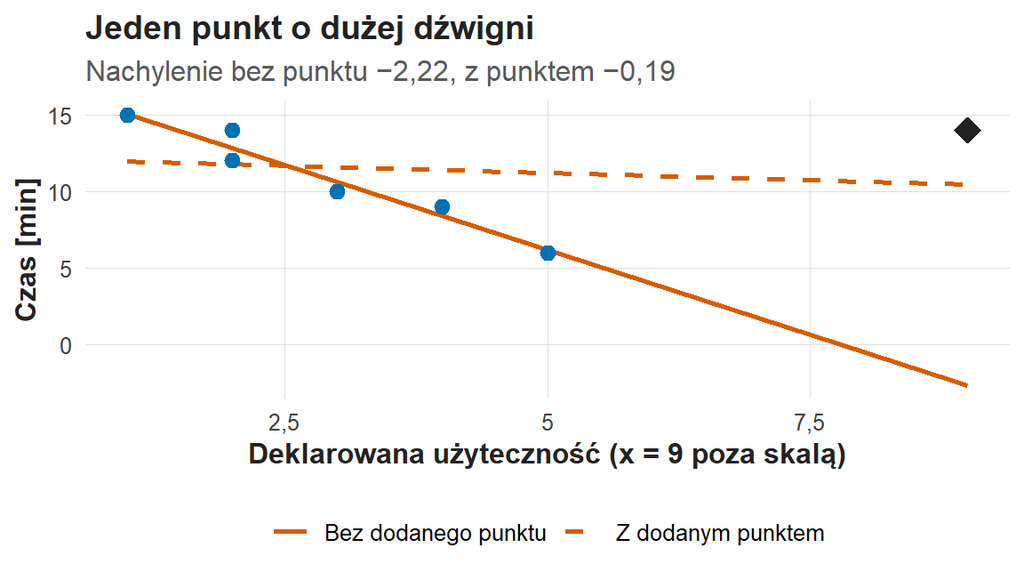

Jeden punkt o dużej dźwigni. Oś pozioma: deklarowana użyteczność; oś pionowa: czas w minutach. Sześć kół to pierwotne pary, romb to punkt dodany przy x = 9 i y = 14 minut. Linia ciągła (bez dodanego punktu) ma nachylenie −2,22 minuty na punkt; linia przerywana (z punktem) ma nachylenie −0,19 i jest prawie pozioma.

# Przedział średniej a przedział predykcji

Dla x = 3 zadaje się dwa pytania: o średni czas osób z indeksem 3 albo o czas nowej osoby. Oba przedziały mają postać:

$$\widehat{y}_0\pm t_{0{,}975;\,n-2}\,s_e\sqrt{\frac{1}{n}+\frac{(x_0-\bar{x})^2}{\sum(x_i-\bar{x})^2}},\qquad
\widehat{y}_0\pm t_{0{,}975;\,n-2}\,s_e\sqrt{1+\frac{1}{n}+\frac{(x_0-\bar{x})^2}{\sum(x_i-\bar{x})^2}} .$$

Składnik 1 pod drugim pierwiastkiem to zmienność indywidualna, więc przedział predykcji jest szerszy przy tych samych założeniach. Tabela „Prognoza przy x = 3” podaje prognozę 10,63 minuty, przedział średniej warunkowej [9,67; 11,59] (±0,96) i przedział dla nowej osoby [8,11; 13,16] (±2,53).

Prognoza przy x = 3

| Przedział | Prognoza [min] | 95% przedział [min] |
| --- | --- | --- |
| Średnia warunkowa przy x = 3 | 10,63 | [9,67; 11,59] |
| Nowa osoba z x = 3 | 10,63 | [8,11; 13,16] |

Przedział predykcji obejmuje czas nowej osoby z prawdopodobieństwem 95% przy założeniach modelu; oba pasma na wykresie „Sześć par do nauki odczytu” są najwęższe przy średniej x = 2,83. Prognoza obejmuje zakres obserwowanych x, od 1 do 5. W ćwiczeniu C08 ujemne granice predykcji czasu sygnalizują ograniczenie modelu normalnego.

# Kalibracja samooceny: zgodność poziomów

W osobnym, hipotetycznym badaniu pięć osób przewiduje własny wynik testu w procentach, a następnie rozwiązuje test. Oba wyniki odnoszą się do tego samego zadania i mają wspólną jednostkę. Tabela „Kalibracja samooceny” podaje wyniki 20, 30, 40, 50 i 60% oraz samooceny 40, 50, 60, 70 i 80%; każda samoocena przewyższa wynik o 20 punktów procentowych.

Kalibracja samooceny

| Osoba | Wynik [%] | Samoocena [%] | Błąd samooceny [pp] |
| --- | --- | --- | --- |
| 1 | 20 | 40 | 20 |
| 2 | 30 | 50 | 20 |
| 3 | 40 | 60 | 20 |
| 4 | 50 | 70 | 20 |
| 5 | 60 | 80 | 20 |

Średni błąd samooceny i granice zgodności Blanda–Altmana mają postać:

$$\bar{b}=\frac{1}{n}\sum_{i=1}^{n}(\text{samoocena}_i-\text{wynik}_i)=20 \text{ pp},\qquad \bar{b}\pm1{,}96\,s_b ,$$

gdzie $s_b$ to SD różnic; tu $s_b=0$, więc granice pokrywają się ze średnim błędem.

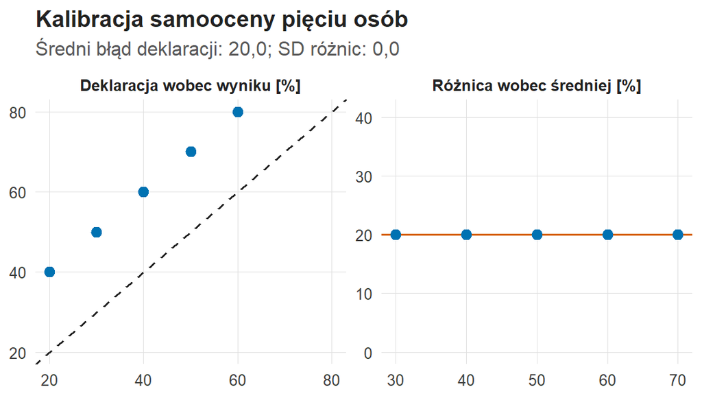

Kalibracja samooceny pięciu osób. Lewy panel: samoocena wobec wyniku w procentach; pięć punktów leży na prostej równoległej do linii zgodności y = x (przerywanej), 20 punktów procentowych nad nią. Prawy panel: różnica samoocena minus wynik wobec średniej obu pomiarów; wszystkie pięć różnic wynosi 20, na linii średniego błędu.

Korelacja wynosi 1, a każda osoba zawyża wynik o 20 punktów procentowych. Korelacja opisuje zgodność kolejności osób, a kalibracja — zgodność poziomów. Błąd samooceny liczy się dla wyników w tej samej jednostce, np. przewidywanego i uzyskanego procentu poprawnych odpowiedzi; operacjonalizacja określa sensowny rachunek.

# Od tabeli do argumentu

Akapit wyników zawiera pytanie, N par, wybraną miarę, przedział z nazwą metody, wynik testu, p permutacyjne i B przy Monte Carlo. Część regresyjna podaje nachylenie z jednostką i przedziałem, $R^2$ oraz ograniczenie diagnostyczne. Akapit zawiera liczby, od których zależy wniosek.

Następny akapit odpowiada merytorycznie: co wynik oznacza dla obserwowanego zachowania, jakie pytania pozostają otwarte i jakie dodatkowe dane są potrzebne. Zdanie „wyższa ocena współwystępowała z krótszym czasem” opisuje związek, a zdanie „lepsza ocena skracała czas” — skutek; czasownik odpowiada projektowi.

Wybór najmniejszego p spośród wielu korelacji zmienia poziom $\alpha$ (wykład W03). Analizę poszukiwawczą nazywa się eksploracyjną, a zaplanowane pytania, reguły braków i metody zapisuje się przed oglądaniem wyników. Walidacja wyniku eksploracyjnego wymaga nowych danych.

# Generatywna SI: kontrola argumentu

Rozważmy celowo wadliwą propozycję interpretacji: „Ponieważ r = −0,30 i p = 0,08, prawdopodobieństwo braku efektu wynosi 8%. Kompetencje skracają czas o 30%, a większa próba na pewno potwierdzi tę zależność”. Liczby służą ćwiczeniu krytycznej lektury i pochodzą spoza sześciu par wykładowych.

Kontrola obejmuje cztery ogniwa argumentu. Nazwa konstruktu odpowiada pytaniom ankiety; r opisuje siłę liniowego związku na skali od −1 do 1; p jest prawdopodobieństwem warunkowym przy $H_0$; obserwacyjny związek opisuje współwystępowanie. Większa próba poprawia precyzję przy spełnionych założeniach, a jakość pomiaru pozostaje osobną sprawą. Pełny odczyt wymaga N, przedziału i informacji o metodzie.

Poprawiona część opisowa brzmi: „Współczynnik liniowego związku deklarowanej użyteczności z czasem wynosił −0,30, p = 0,08; przy α = 0,05 hipoteza zerowej korelacji pozostaje. Ocena precyzji i zakresu uogólnienia wymaga N, przedziału i opisu projektu”.

Tę samą kontrolę stosuje się do podpowiedzi generatywnej SI, zdania w publikacji i własnego szkicu. SI wspiera rozumienie symboli i komunikatów kodu; wynik porównuje się z tabelą, a źródło otwiera i sprawdza. Interpretację student pisze samodzielnie, zgodnie z zasadą kursu podaną w wykładzie W01; korzystanie z usług zewnętrznych jest dobrowolne.

# Dyskusja i przejście do projektu

Zdanie do poprawy: „r = −0,30 oznacza, że katalog poprawia kompetencje o 30%, a model przewiduje poprawnie 9% osób”. Zawiera trzy błędy: przyczynowość, utożsamienie korelacji z procentem zmiany i odczyt $R^2=0{,}09$ jako odsetka trafnych prognoz. Poprawiona wersja brzmi: „Deklarowana użyteczność katalogu i czas zadania korelują na poziomie −0,30; prosta regresji przypisuje 9% sumy kwadratów odchyleń czasu różnicom w ocenie”.

Ćwiczenie C08 przeprowadza pełną analizę na zbiorze S02, którego związek jest znacznie słabszy niż w sześciu parach wykładu. Ćwiczenie C09 (Warsztat projektu: od scenariusza do dwóch małych analiz) łączy pytania z estymandami i planem pomiaru. Ćwiczenie C10 (Od wyniku do raportu: interpretacja, ograniczenia i odtwarzalność) sprawdza, czy każde zdanie raportu ma dowód w wynikach, a rekomendacja mieści się w projekcie.

# Rozwinięcia: model nieliniowy i galeria odczytu

Przykłady rozszerzają zakres metod i wizualizacji i należą do materiału nieocenianego. Każdy ma odrębne, hipotetyczne dane. Celem jest rozpoznanie pytania, na które odpowiada wykres lub parametr.

## Nieliniowa zależność a model nieliniowy

Krzywa zależność ma dwie postaci modelu: liniową w parametrach, np. $\beta_0+\beta_1x+\beta_2x^2$, i nieliniową w parametrach, np. $E(Y\mid x)=a+b\,e^{-cx}$, gdzie nieznany parametr $c$ występuje w wykładniku. Skrypt dopasowuje drugą postać metodą nieliniowych najmniejszych kwadratów.

Demonstracja zakłada, że czas maleje wraz z liczbą wcześniejszych prób, a spadek słabnie. Przy dodatnich $b$ i $c$ parametr $a$ opisuje dolną asymptotę średniej, $a+b$ — czas przy x = 0, a $c$ — tempo spadku. Spadek średniego czasu zmienia się z x: pochodna, czyli tempo zmiany średniego czasu przy małej zmianie x, wynosi $-bc\,e^{-cx}$. Dopasowane parametry to $a=2{,}98$ minuty, $b=12{,}08$ minuty i $c=0{,}401$ na próbę. Tabela „Przewidywane czasy krzywej” podaje czasy 15,06 (0 prób), 11,07 (1), 8,40 (2), 5,41 (4) i 3,47 minuty (8); spadek od 0 do 1 próby wynosi 3,99 minuty, a od 1 do 2 — 2,67 minuty.

Przewidywane czasy krzywej

| Wcześniejsze próby | Średni czas [min] |
| --- | --- |
| 0 | 15,06 |
| 1 | 11,07 |
| 2 | 8,40 |
| 4 | 5,41 |
| 8 | 3,47 |

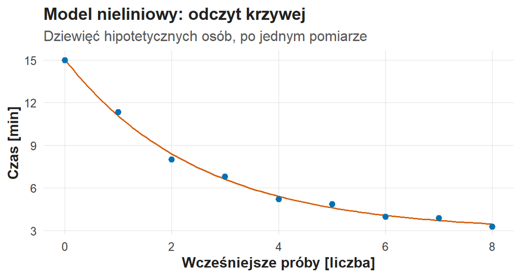

Model nieliniowy: odczyt krzywej. Oś pozioma: wcześniejsze próby od 0 do 8; oś pionowa: czas w minutach. Dziewięć punktów, po jednej osobie na liczbę prób, leży blisko krzywej malejącej od 15 minut przy zerze i spłaszczającej się ku 3 minutom przy ośmiu próbach.

Krzywa opisuje dane dziewięciu osób, każda z jednym pomiarem; mechanizm uczenia się wymaga pomiarów powtarzanych u tych samych osób. Asymptota $a=2{,}98$ minuty jest parametrem modelu, a prognozy obejmują zakres 0–8 prób. Użycie praktyczne wymaga sprawdzenia reszt, stabilności dopasowania i niepewności parametrów. [Dokumentacja nls](https://stat.ethz.ch/R-manual/R-devel/library/stats/html/nls.html).

## Wykres wiolinowy: kształt rozkładu

Wykres wiolinowy łączy obraz gęstości z położeniem wartości: szerokie miejsce wskazuje skupienie obserwacji, a wąskie — wartości rzadsze według wygładzenia. Pudełko wewnątrz przedstawia medianę i kwartyle. Dwie grupy po dwanaście hipotetycznych czasów mają tę samą regułę wygładzenia.

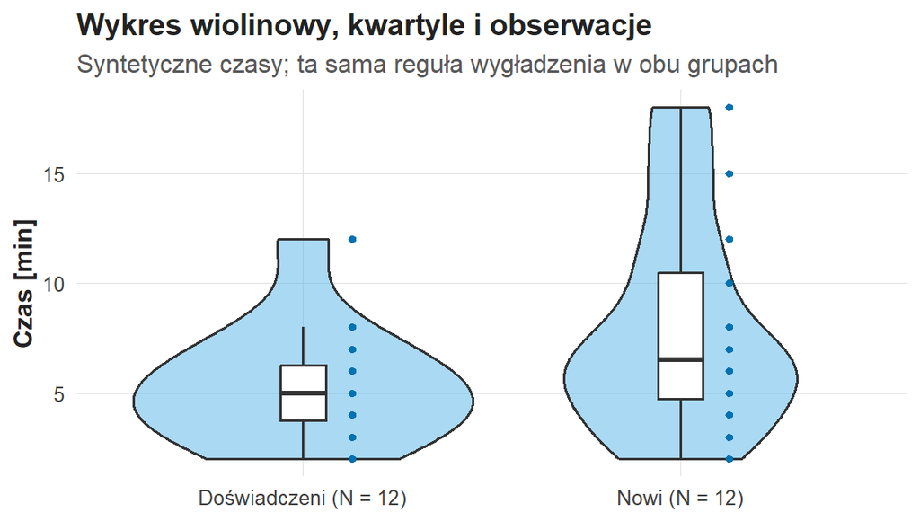

Wykres wiolinowy, kwartyle i obserwacje dwóch grup po 12 osób. Oś pozioma: grupa; oś pionowa: czas w minutach. Nowi: mediana 6,5 minuty, kwartyle 4,75 i 10,5, maksimum 18; wiolina ma długi górny ogon. Doświadczeni: mediana 5 minut, kwartyle 3,75 i 6,25, maksimum 12; wiolina jest skupiona między 2 a 8 minutami.

Liczebność podaje etykieta grupy (N = 12), bo nakładające się punkty zakrywają identyczne wartości. Szerokość wygładzania zmienia kształt, więc dwie wypukłości w małej próbie wymagają potwierdzenia w większych danych. [Dokumentacja geom_violin](https://ggplot2.tidyverse.org/reference/geom_violin.html).

## Pareto: od częstości barier do udziału skumulowanego

Biblioteka koduje główną barierę każdego z trzydziestu zgłoszeń. Każde zgłoszenie otrzymuje jedną kategorię, a jedna osoba mogła zgłosić kilka problemów, więc N oznacza zgłoszenia. Wykres Pareto porządkuje kategorie od najczęstszej i dodaje udział skumulowany.

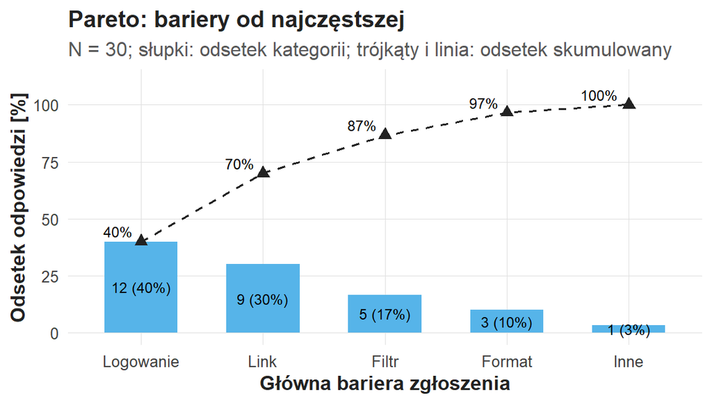

Pareto: bariery od najczęstszej, 30 zgłoszeń. Oś pozioma: główna bariera zgłoszenia; oś pionowa: odsetek zgłoszeń. Słupki: logowanie 12 (40%), link 9 (30%), filtr 5 (17%), format 3 (10%), inne 1 (3%). Trójkąty połączone linią przerywaną: udział skumulowany 40, 70, 87, 97 i 100%.

Dwie kategorie obejmują 70% zgłoszeń. Priorytet naprawy łączy częstość z powagą problemu, liczbą osób, które problem napotkały, i kosztem zmiany.

## Wykres kołowy: podział całości

W osobnej demonstracji zapisano jedno urządzenie użyte w bieżącej sesji przez każdą z 48 osób; kategorie są rozłączne i wyczerpują odpowiedzi, więc udziały tworzą części jednego koła. Tabela „Urządzenie bieżącej sesji” podaje: komputer 24 z 48 osób (50%), telefon 16 (33,3%), tablet 8 (16,7%).

Urządzenie bieżącej sesji

| Urządzenie | N | Udział [%] |
| --- | --- | --- |
| Komputer | 24 | 50,0 |
| Telefon | 16 | 33,3 |
| Tablet | 8 | 16,7 |

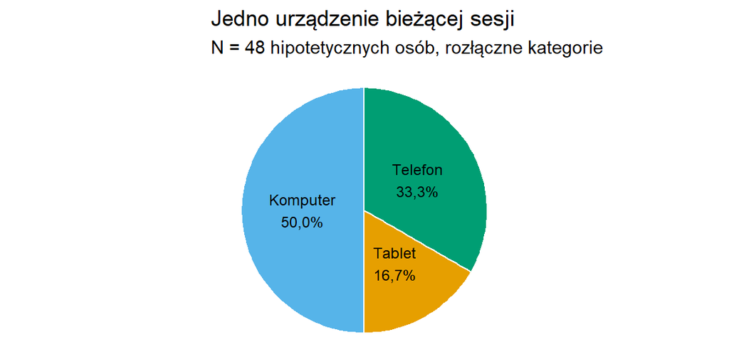

Jedno urządzenie bieżącej sesji, 48 osób. Koło podzielone na trzy wycinki z napisami: komputer 50,0%, telefon 33,3%, tablet 16,7%; wycinek komputera zajmuje połowę koła.

Kanały pomocy z ćwiczenia C04 dopuszczają kilka odpowiedzi, więc ich odsetki przedstawia wykres słupkowy z osią 0–100%. Dokładne porównanie podobnych udziałów jest prostsze na słupkach ze wspólną osią.

## Mapa cieplna: kolor wymaga mianownika

Sześć komórek przedstawia powodzenia w trzech zadaniach i dwóch grupach; każda osoba wykonuje jedno zadanie, a liczebności komórek są różne. Kolor odpowiada odsetkowi na wspólnej skali 0–100%, a napis podaje powodzenia i liczbę prób. Precyzję odsetka opisuje błąd standardowy:

$$SE(\hat{p})=\sqrt{\frac{\hat{p}(1-\hat{p})}{n}}:\qquad \frac{9}{15}\to0{,}126,\qquad \frac{9}{12}\to0{,}125,\qquad \frac{18}{20}\to0{,}067 .$$

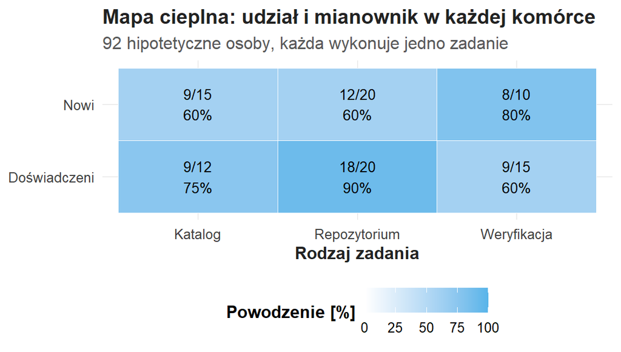

Mapa cieplna: udział i mianownik w każdej komórce. Kolumny: katalog, repozytorium, weryfikacja; wiersze: nowi i doświadczeni. Nowi: 9/15 (60%), 12/20 (60%), 8/10 (80%). Doświadczeni: 9/12 (75%), 18/20 (90%), 9/15 (60%). Najciemniejsza komórka to repozytorium u doświadczonych.

Tabela „Mianowniki i SE sześciu komórek” podaje odsetek i jego SE w każdej komórce. Dziewięć powodzeń daje 60% przy N = 15 i 75% przy N = 12; komórki o podobnym kolorze mają różne mianowniki i podobną precyzję (SE 0,13), a komórka 18/20 ma SE 0,07.

Mianowniki i SE sześciu komórek

| Grupa | Zadanie | N | Powodzenia | Odsetek [%] | SE odsetka |
| --- | --- | --- | --- | --- | --- |
| Nowi | Katalog | 15 | 9 | 60,0 | 0,126 |
| Nowi | Repozytorium | 20 | 12 | 60,0 | 0,110 |
| Nowi | Weryfikacja | 10 | 8 | 80,0 | 0,126 |
| Doświadczeni | Katalog | 12 | 9 | 75,0 | 0,125 |
| Doświadczeni | Repozytorium | 20 | 18 | 90,0 | 0,067 |
| Doświadczeni | Weryfikacja | 15 | 9 | 60,0 | 0,126 |

## Wydajność usługi: czas odpowiedzi i przepustowość

Czas odpowiedzi serwera, przepustowość i czas wyszukiwania osoby to trzy wyniki; każdy wymaga osobnego pomiaru. Czas wyszukiwania osoby obejmuje czytanie i podejmowanie decyzji, czas odpowiedzi serwera — żądanie techniczne, a przepustowość — liczbę zakończonych żądań na sekundę. Hipotetyczny test ma pięć ustawień równoczesnego obciążenia przy tej samej konfiguracji.

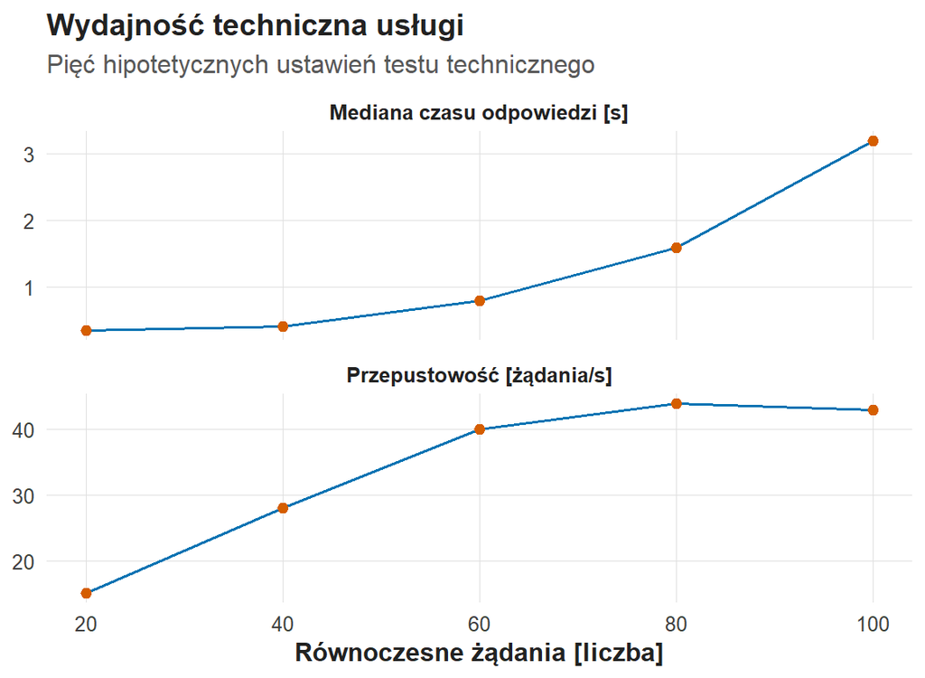

Wydajność techniczna usługi przy 20, 40, 60, 80 i 100 równoczesnych żądaniach. Górny panel: mediana czasu odpowiedzi rośnie z 0,35 do 0,42, 0,8, 1,6 i 3,2 sekundy. Dolny panel: przepustowość rośnie z 15 do 28 i 40 żądań na sekundę, a potem zatrzymuje się przy 44 i 43.

Przy wzroście obciążenia z 60 do 100 żądań mediana odpowiedzi rośnie z 0,8 do 3,2 sekundy, a przepustowość z 40 do 43 żądań na sekundę: dalsze obciążenie wydłuża oczekiwanie bez proporcjonalnego wzrostu obsługi. Ocena usługi wymaga powtórzeń, skrajnych kwantyli opóźnienia, liczby błędów i wyników zadań użytkowników.

## Reszty cząstkowe: odczyt rozszerzenia

Regresja z dwoma predyktorami ma postać $Y_i=\beta_0+\beta_1x_i+\beta_2w_i+\varepsilon_i$: $x$ liczy wcześniejsze próby, a $w$ to umowny poziom trudności zadania 1–3, traktowany w demonstracji jako skala o równych odstępach. Model dwóch predyktorów należy do rozszerzenia. Dopasowany model to: czas = 18,26 − 0,523·praktyka + 1,949·trudność.

Zwykła reszta $e_i$ porównuje obserwowany czas z całym przewidywaniem. Wykres reszt cząstkowych dla x ma na osi pionowej $e_i+b_1x_i$: resztę z dodanym składnikiem praktyki, w minutach, z linią odniesienia $b_1x$.

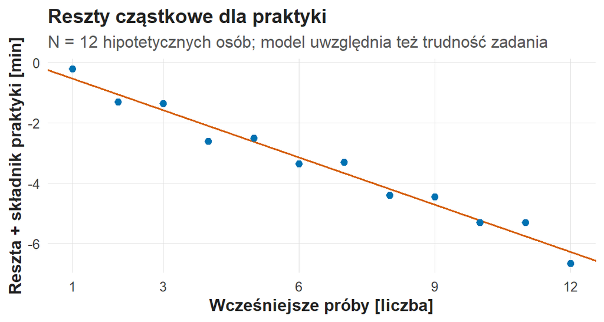

Reszty cząstkowe dla praktyki, 12 hipotetycznych osób. Oś pozioma: wcześniejsze próby od 1 do 12; oś pionowa: reszta z dodanym składnikiem praktyki w minutach. Punkty leżą blisko prostej o nachyleniu −0,523 minuty na próbę, od około −0,5 przy jednej próbie do około −6,3 przy dwunastu.

Wykres opisuje składnik modelu przy uwzględnionej trudności; interpretacja zależy od pozostałych elementów modelu i zakresu danych. Programy centrują czasem składniki, co przesuwa obraz w pionie, więc odczyt zaczyna się od definicji osi. [Dokumentacja termplot](https://stat.ethz.ch/R-manual/R-devel/library/stats/html/termplot.html).

Wspólny wniosek z galerii: najpierw ustala się jednostkę obserwacji, licznik i mianownik, potem wielkość zakodowaną przez pozycję, pole lub kolor, a na końcu wzorzec i jego ograniczenie. Raport używa wykresów, które odpowiadają na pytanie badawcze.

# Literatura do dalszej pracy

- Hargittai, E. (2002). *Beyond logs and surveys: In-depth measures of people’s web use skills*. JASIST, 53(14), 1239–1244. [Strona autorki](https://webuse.org/p/a09/).
- van Deursen, A.J.A.M., Helsper, E.J., Eynon, R. (2016). *Development and validation of the Internet Skills Scale (ISS)*. Information, Communication & Society, 19(6), 804–823. [Repozytorium LSE](https://eprints.lse.ac.uk/64485/).
- Vuorikari, R., Kluzer, S., Punie, Y. (2022). *DigComp 2.2*. JRC128415; Association of College and Research Libraries (2016). *Framework for Information Literacy for Higher Education*. [Dokument ACRL](https://www.ala.org/acrl/standards/ilframework).
- Anscombe, F.J. (1973). *Graphs in statistical analysis*. The American Statistician, 27(1), 17–21. [DOI](https://doi.org/10.1080/00031305.1973.10478966).
- Dokumentacja R: [cor.test](https://stat.ethz.ch/R-manual/R-devel/library/stats/html/cor.test.html), [predict.lm](https://stat.ethz.ch/R-manual/R-devel/library/stats/html/predict.lm.html).

Przykłady liczbowe wykładu są dydaktyczne; wyniki cytowanych prac zawierają ich publikacje.